# Red Wine Quality by Eduardo Dionisio Gamarra

> **The Dataset**: The dataset is a csv file containing 1599 observations about red wines, it have 13 variables associated to them (1 id variable + 11 attributes variables + 1 output variable).

> **The main question**: The main question is to discover: What chemical properties influence the quality of red wines? I will try to answer the question by performing Exploratory Data Analysis (EDA) of the dataset.

# Univariate Plots Section

#### Structure and summary Of The Dataset

Let’s take a look at how our data is structured.

```
## 'data.frame':    1599 obs. of  13 variables:
##  $ X                   : int  1 2 3 4 5 6 7 8 9 10 ...
##  $ fixed.acidity       : num  7.4 7.8 7.8 11.2 7.4 7.4 7.9 7.3 7.8 7.5 ...
##  $ volatile.acidity    : num  0.7 0.88 0.76 0.28 0.7 0.66 0.6 0.65 0.58 0.5 ...
##  $ citric.acid         : num  0 0 0.04 0.56 0 0 0.06 0 0.02 0.36 ...
##  $ residual.sugar      : num  1.9 2.6 2.3 1.9 1.9 1.8 1.6 1.2 2 6.1 ...
##  $ chlorides           : num  0.076 0.098 0.092 0.075 0.076 0.075 0.069 0.065 0.073 0.071 ...
##  $ free.sulfur.dioxide : num  11 25 15 17 11 13 15 15 9 17 ...
##  $ total.sulfur.dioxide: num  34 67 54 60 34 40 59 21 18 102 ...
##  $ density             : num  0.998 0.997 0.997 0.998 0.998 ...
##  $ pH                  : num  3.51 3.2 3.26 3.16 3.51 3.51 3.3 3.39 3.36 3.35 ...
##  $ sulphates           : num  0.56 0.68 0.65 0.58 0.56 0.56 0.46 0.47 0.57 0.8 ...
##  $ alcohol             : num  9.4 9.8 9.8 9.8 9.4 9.4 9.4 10 9.5 10.5 ...
##  $ quality             : int  5 5 5 6 5 5 5 7 7 5 ...
```

```
##        X          fixed.acidity   volatile.acidity  citric.acid
##  Min.   :   1.0   Min.   : 4.60   Min.   :0.1200   Min.   :0.000
##  1st Qu.: 400.5   1st Qu.: 7.10   1st Qu.:0.3900   1st Qu.:0.090
##  Median : 800.0   Median : 7.90   Median :0.5200   Median :0.260
##  Mean   : 800.0   Mean   : 8.32   Mean   :0.5278   Mean   :0.271
##  3rd Qu.:1199.5   3rd Qu.: 9.20   3rd Qu.:0.6400   3rd Qu.:0.420
##  Max.   :1599.0   Max.   :15.90   Max.   :1.5800   Max.   :1.000
##  residual.sugar     chlorides       free.sulfur.dioxide
##  Min.   : 0.900   Min.   :0.01200   Min.   : 1.00
##  1st Qu.: 1.900   1st Qu.:0.07000   1st Qu.: 7.00
##  Median : 2.200   Median :0.07900   Median :14.00
##  Mean   : 2.539   Mean   :0.08747   Mean   :15.87
##  3rd Qu.: 2.600   3rd Qu.:0.09000   3rd Qu.:21.00
##  Max.   :15.500   Max.   :0.61100   Max.   :72.00
##  total.sulfur.dioxide    density             pH          sulphates
##  Min.   :  6.00       Min.   :0.9901   Min.   :2.740   Min.   :0.3300
##  1st Qu.: 22.00       1st Qu.:0.9956   1st Qu.:3.210   1st Qu.:0.5500
##  Median : 38.00       Median :0.9968   Median :3.310   Median :0.6200
##  Mean   : 46.47       Mean   :0.9967   Mean   :3.311   Mean   :0.6581
##  3rd Qu.: 62.00       3rd Qu.:0.9978   3rd Qu.:3.400   3rd Qu.:0.7300
##  Max.   :289.00       Max.   :1.0037   Max.   :4.010   Max.   :2.0000
##     alcohol         quality
##  Min.   : 8.40   Min.   :3.000
##  1st Qu.: 9.50   1st Qu.:5.000
##  Median :10.20   Median :6.000
##  Mean   :10.42   Mean   :5.636
##  3rd Qu.:11.10   3rd Qu.:6.000
##  Max.   :14.90   Max.   :8.000
```

I gonna make some changes at the dataset: First I am renaming the ‘x’ variable to ‘wine.id’ to make it more intuitive. I also think that is a good idea to transform the variable ‘quality’ from an Integer to a Factor. And for last, I will create a factoral variable ‘rank’ to better classification of quality, it will be (bad, medium and good)

Now let’s visualize the structure after the changes.

```
## 'data.frame':    1599 obs. of  14 variables:
##  $ wine.id             : int  1 2 3 4 5 6 7 8 9 10 ...
##  $ fixed.acidity       : num  7.4 7.8 7.8 11.2 7.4 7.4 7.9 7.3 7.8 7.5 ...
##  $ volatile.acidity    : num  0.7 0.88 0.76 0.28 0.7 0.66 0.6 0.65 0.58 0.5 ...
##  $ citric.acid         : num  0 0 0.04 0.56 0 0 0.06 0 0.02 0.36 ...
##  $ residual.sugar      : num  1.9 2.6 2.3 1.9 1.9 1.8 1.6 1.2 2 6.1 ...
##  $ chlorides           : num  0.076 0.098 0.092 0.075 0.076 0.075 0.069 0.065 0.073 0.071 ...
##  $ free.sulfur.dioxide : num  11 25 15 17 11 13 15 15 9 17 ...
##  $ total.sulfur.dioxide: num  34 67 54 60 34 40 59 21 18 102 ...
##  $ density             : num  0.998 0.997 0.997 0.998 0.998 ...
##  $ pH                  : num  3.51 3.2 3.26 3.16 3.51 3.51 3.3 3.39 3.36 3.35 ...
##  $ sulphates           : num  0.56 0.68 0.65 0.58 0.56 0.56 0.46 0.47 0.57 0.8 ...
##  $ alcohol             : num  9.4 9.8 9.8 9.8 9.4 9.4 9.4 10 9.5 10.5 ...
##  $ quality             : Ord.factor w/ 6 levels "3"<"4"<"5"<"6"<..: 3 3 3 4 3 3 3 5 5 3 ...
##  $ rank                : Ord.factor w/ 3 levels "bad"<"medium"<..: 2 2 2 2 2 2 2 3 3 2 ...
```

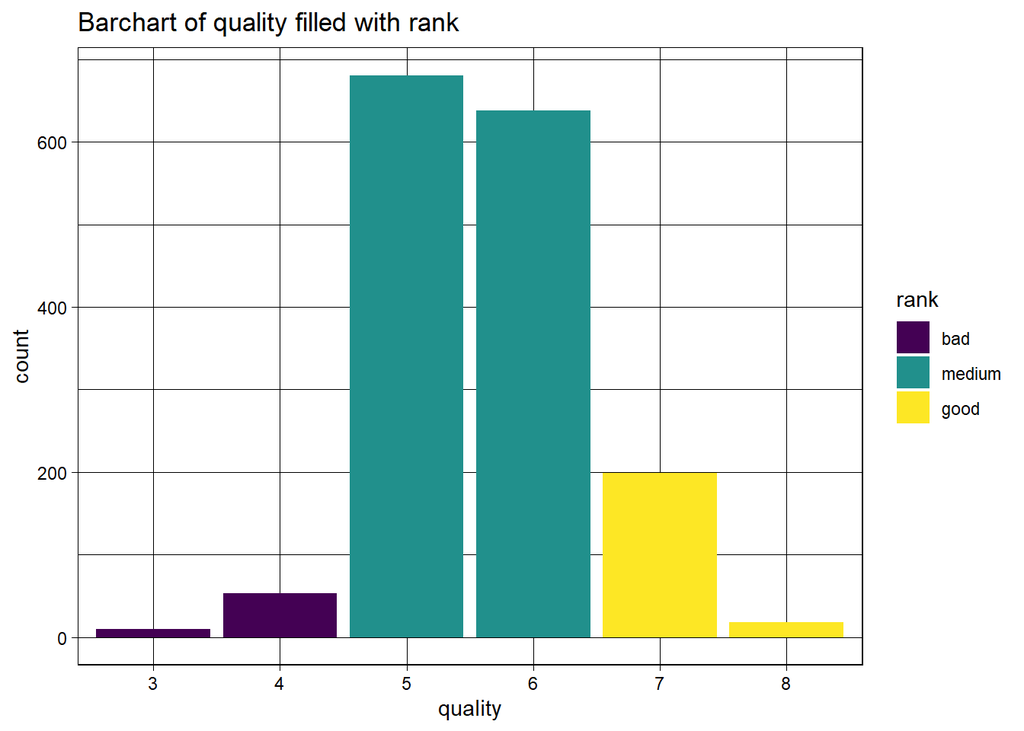

The plot matches the dataset documentation that tells us the classes are not balanced, most of the wines have the medium quality. I will explore the distribution of the variables:

#### Fixed acidity

fixed acidity (tartaric acid - g / dm^3): most acids involved with wine or fixed or nonvolatile (do not evaporate readily).

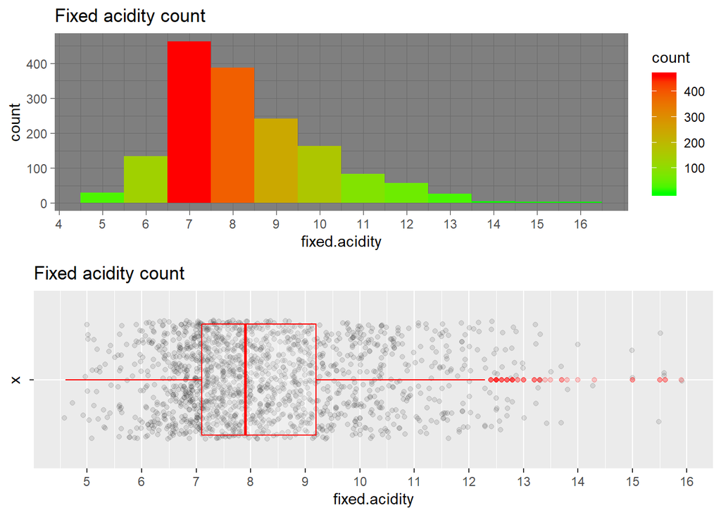

```
##    Min. 1st Qu.  Median    Mean 3rd Qu.    Max.
##    4.60    7.10    7.90    8.32    9.20   15.90
```

Seems like the distribution of Fixed Acidity is positively skewed. The median is around 8, and due to some outliers, the 3 quartile was dragged to around 9.2.

#### Volatile acidity

volatile acidity (acetic acid - g / dm^3): the amount of acetic acid in wine, which at too high of levels can lead to an unpleasant, vinegar taste.

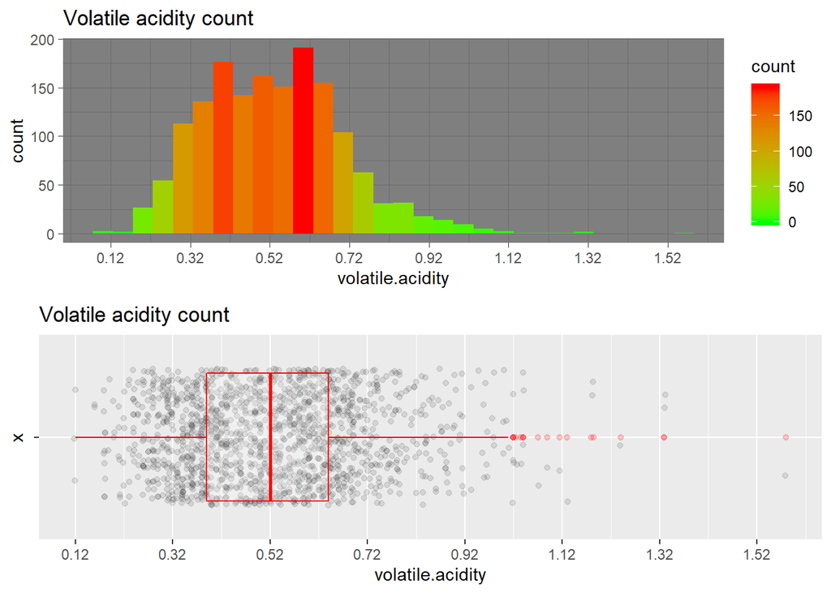

It seems that the distribution of volatile.acidity is also positively skewed. with two peaks at 0.4 and 0.6.

#### Citric acid

citric acid (g / dm^3): found in small quantities, citric acid can add ‘freshness’ and flavor to wines.

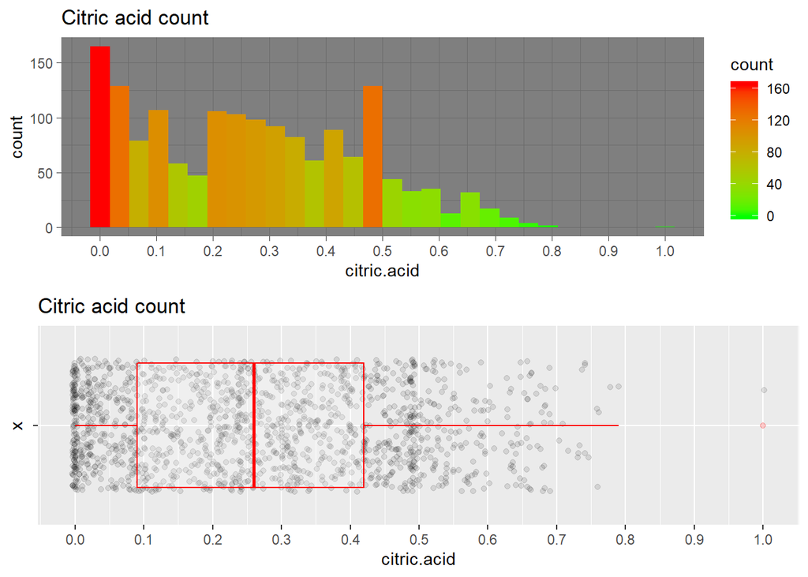

This one is a bit hard to guess if is Skewed by just looking the histogram, but the position of the box is on left of the plot, which suggests that it’s a right skewed box-plot, so we will consider that a positively skewed distribution.

#### Residual sugar

residual sugar (g / dm^3): the amount of sugar remaining after fermentation stops, it’s rare to find wines with less than 1 gram/liter and wines with greater than 45 grams/liter are considered sweet.

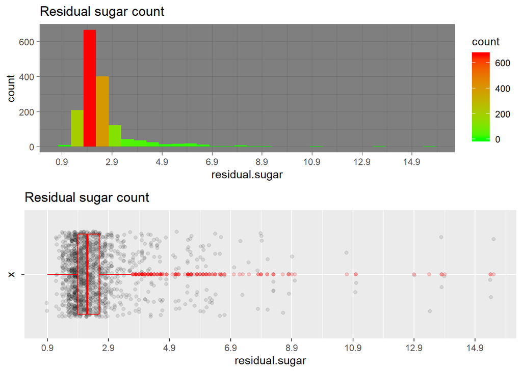

This one is a log tail distribution. It can be transformed by removing some outliers (5%) and applying a log transformation.

#### Chlorides

chlorides (sodium chloride - g / dm^3): the amount of salt in the wine.

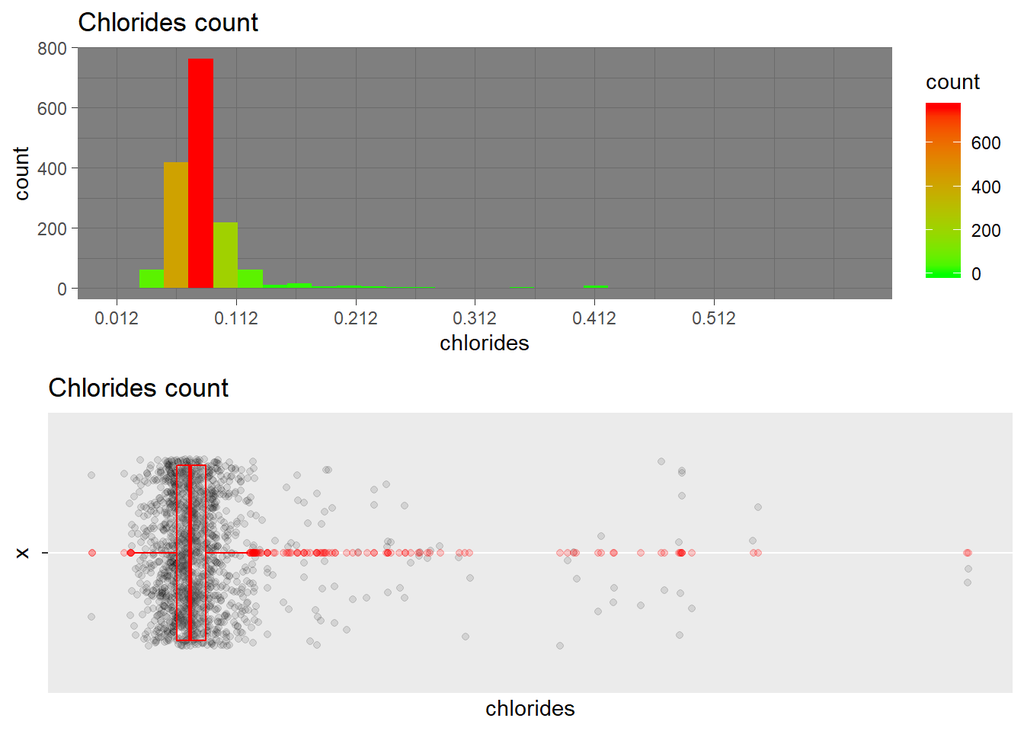

This one is also a long tail distribution. Like the previous one, it can be transformed by removing some outliers (5%) and applying a log transformation.

#### Free sulfur dioxide

free sulfur dioxide (mg / dm^3): the free form of SO2 exists in equilibrium between molecular SO2 (as a dissolved gas) and bisulfite ion; it prevents microbial growth and the oxidation of the wine.

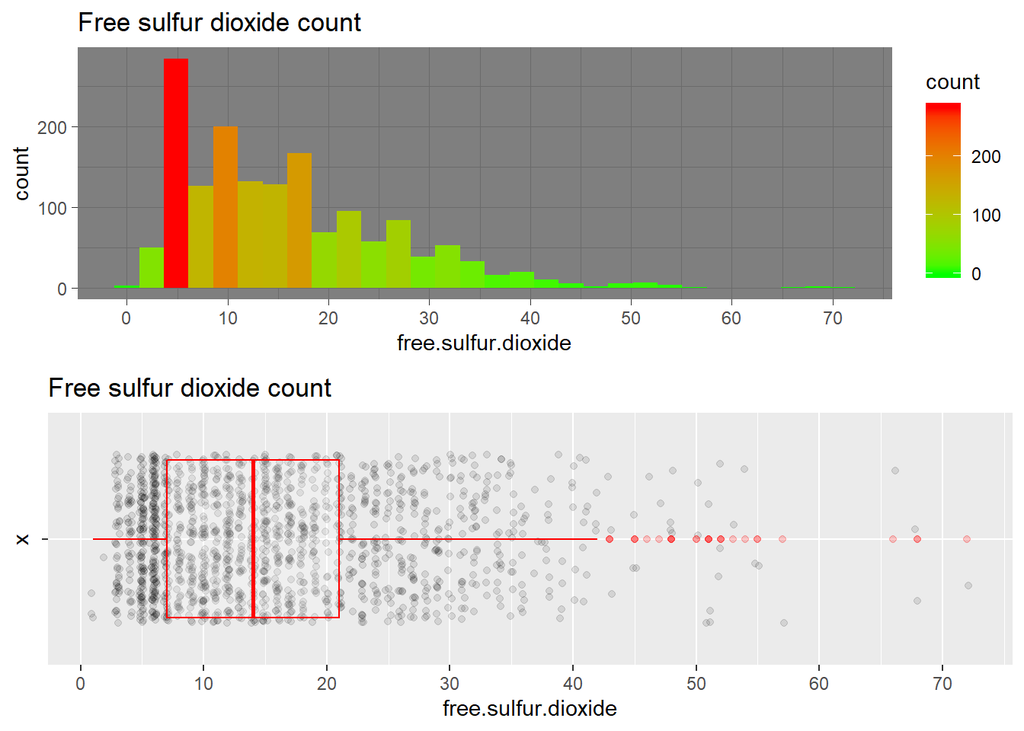

The distribution of free.sulfur.dioxide is positively skewed.

#### Total sulfur dioxide

total sulfur dioxide (mg / dm^3): the amount of free and bound forms of S02; in low concentrations, SO2 is mostly undetectable in wine, but at free SO2 concentrations over 50 ppm, SO2 becomes evident in the nose and taste of wine.

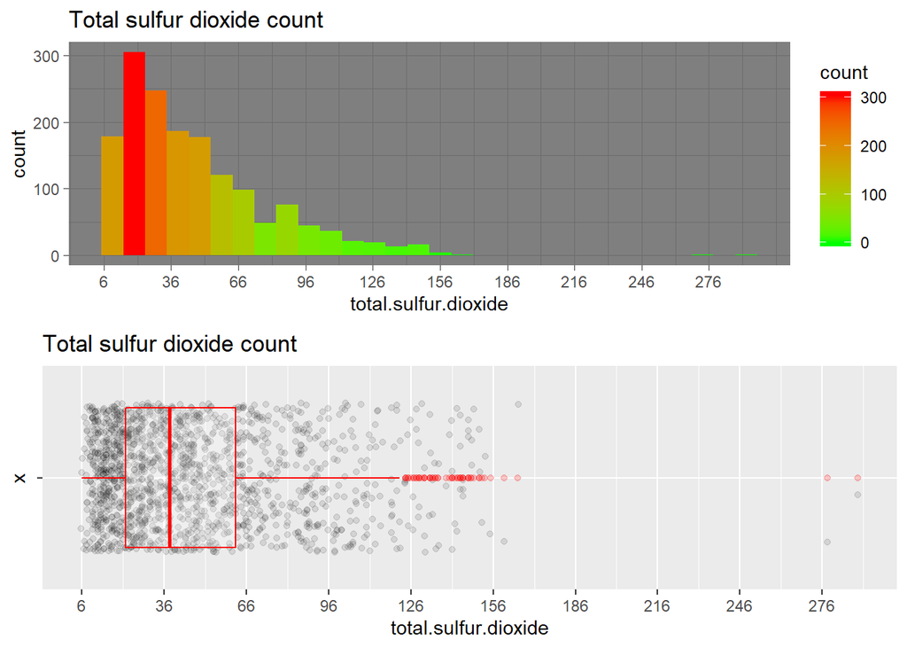

By looking at the graphs, we can say that this distribution as a long tail, but I prefer to classify this one as a positively skewed, because that if you remove the outliers (5%) you will end up with a graph much more reasonable.

#### Density

density (g / cm^3): the density of wine is close to that of water depending on the percent alcohol and sugar content.

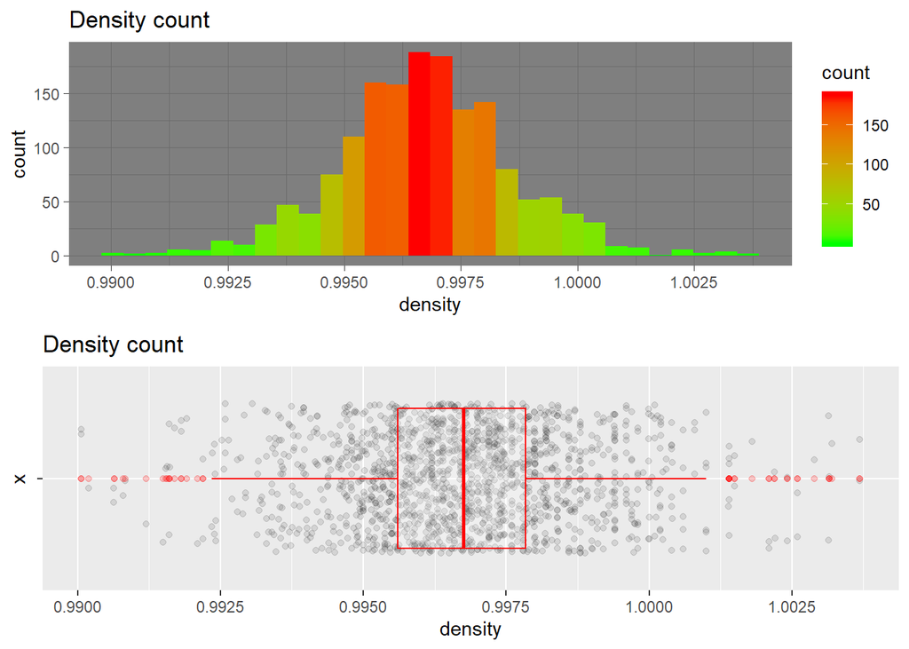

The density has a normal distribution.

#### pH

pH: describes how acidic or basic a wine is on a scale from 0 (very acidic) to 14 (very basic); most wines are between 3-4 on the pH scale.

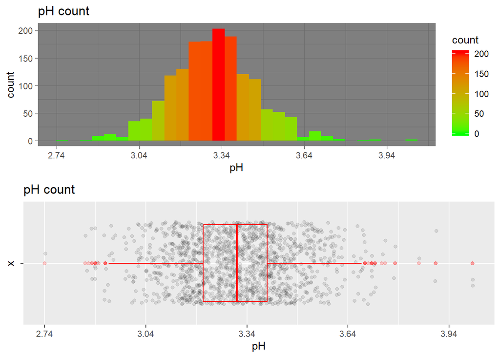

The pH distribution has a normal distribution.

#### Sulphates (potassium sulphate - g / dm3)

sulphates: a wine additive which can contribute to sulfur dioxide gas (S02) levels, which acts as an antimicrobial and antioxidant.

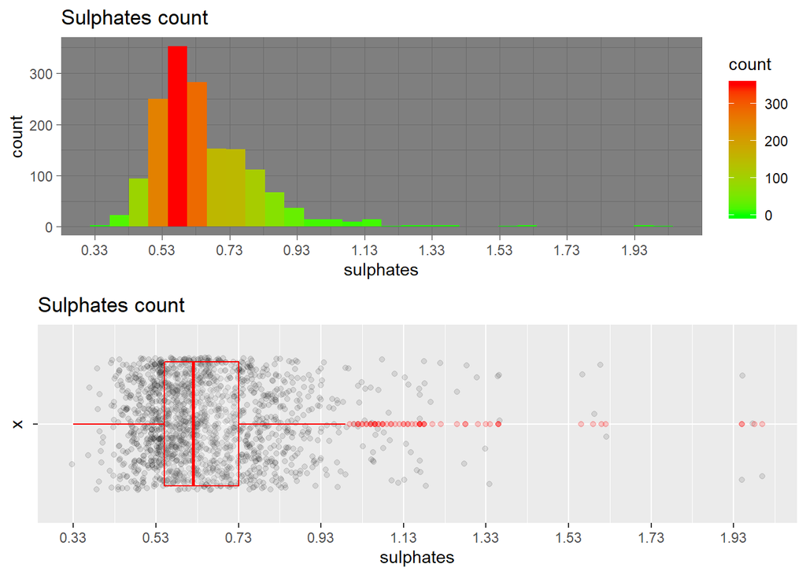

Because this variable is related to sulfur is no surprise that the distribution is positively skewed.

#### Alcohol

Alcohol (% by volume): the percent alcohol content of the wine.

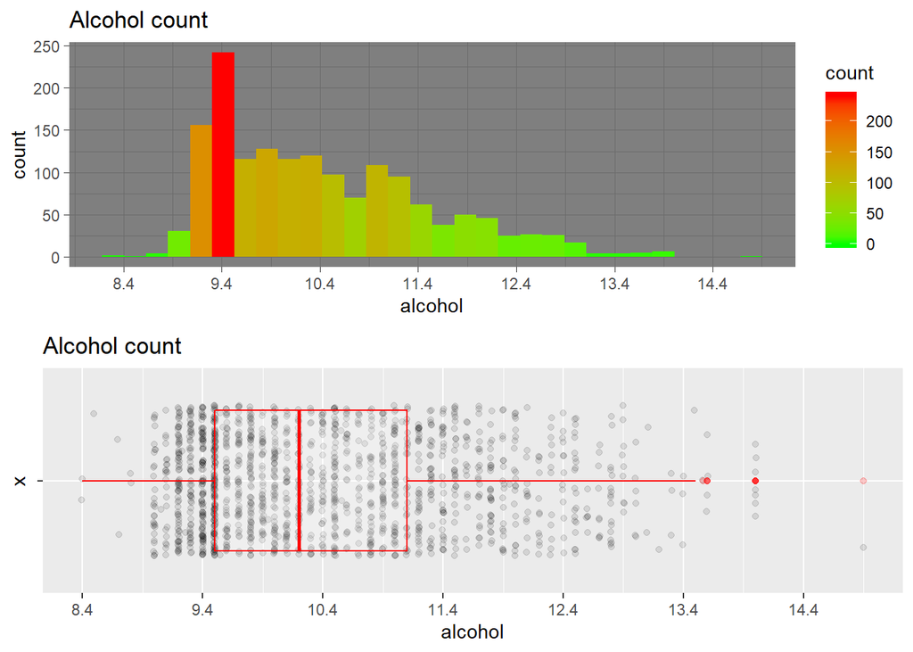

The alcool distribution is slightly positively skewed.

Conclusion :

- *Positively Skewed*: Fixed acidity, Volatile acidity, Citric acid, Free sulfur dioxide, Total sulfur dioxide, Sulphates, Alcohol
- *Long Tail*: Residual sugar, Chlorides
- *Normal*: Density, PH

# Univariate Analysis

### What is the structure of your dataset?

The Red Wine Dataset had 1599 observations and 13 variables originally. I added a variable called ‘rank’. The data set is organized with tidy, and most of the values are float(num) excerpt x(now wine.id) and quality.

### What is/are the main feature(s) of interest in your dataset?

I’m interested in the chemical components, so I’m not interested in density or ph (I’ll not ignore the variables to measure the impact of the chemical components on quality).

### What other features in the dataset do you think will help support your investigation into your feature(s) of interest?

Quality and rank, because they will help me to understand the amount of impact that each chemical component will do on the quality.

### Did you create any new variables from existing variables in the dataset?

Yes, I created the variable rank, a categorical variable.

### Of the features you investigated, were there any unusual distributions? Did you perform any operations on the data to tidy, adjust, or change the form of the data? If so, why did you do this?

There was no needed to change or adjust the data, the outliers seem to be true data values and not input errors. The distributions founded in the data was mostly skewed positively.

# Bivariate Plots Section

The documentation says that several of the variables may be correlated, let’s start by looking at it.

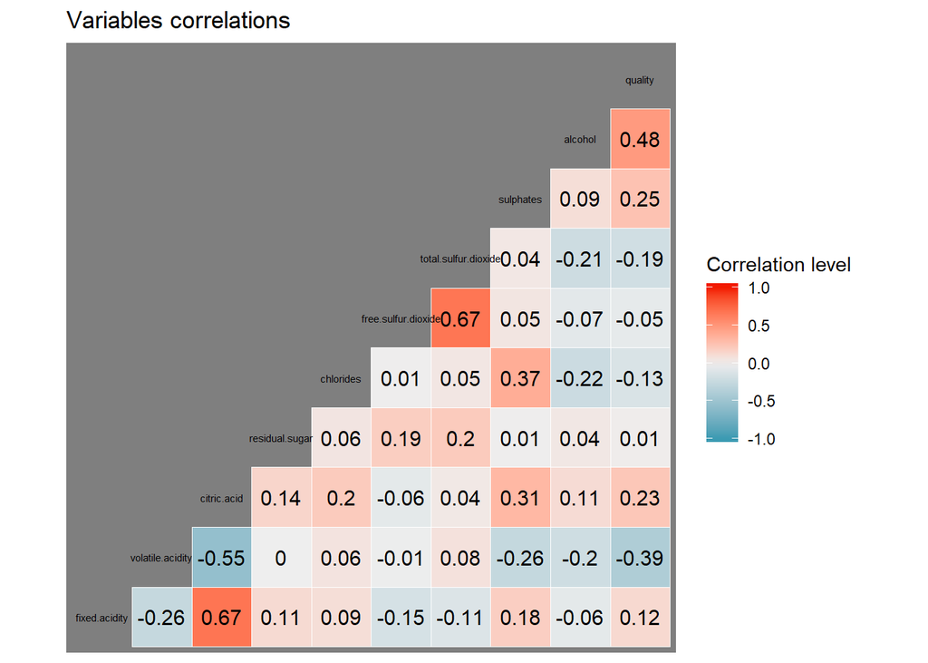

alcohol | 0.48  
volatile.acidity | -0.39  
sulphates | 0.25  
citric.acid | 0.23

Let’s get a close look at this four variables.

#### Quality vs Alcohol

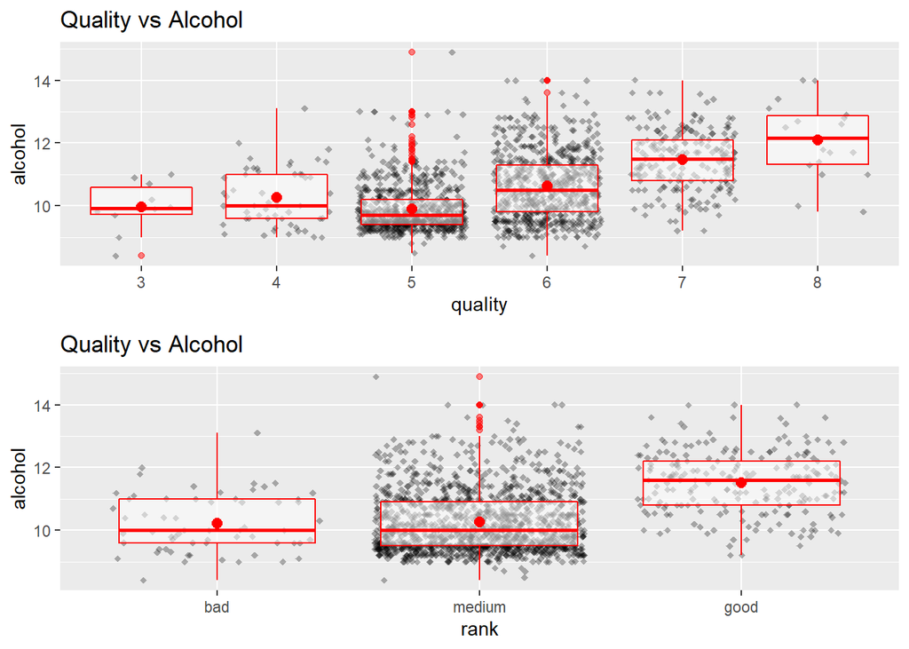

The plot makes it clear that higher quality wines have higher alcohol content.

Now let’s plot Volatile Acidity.

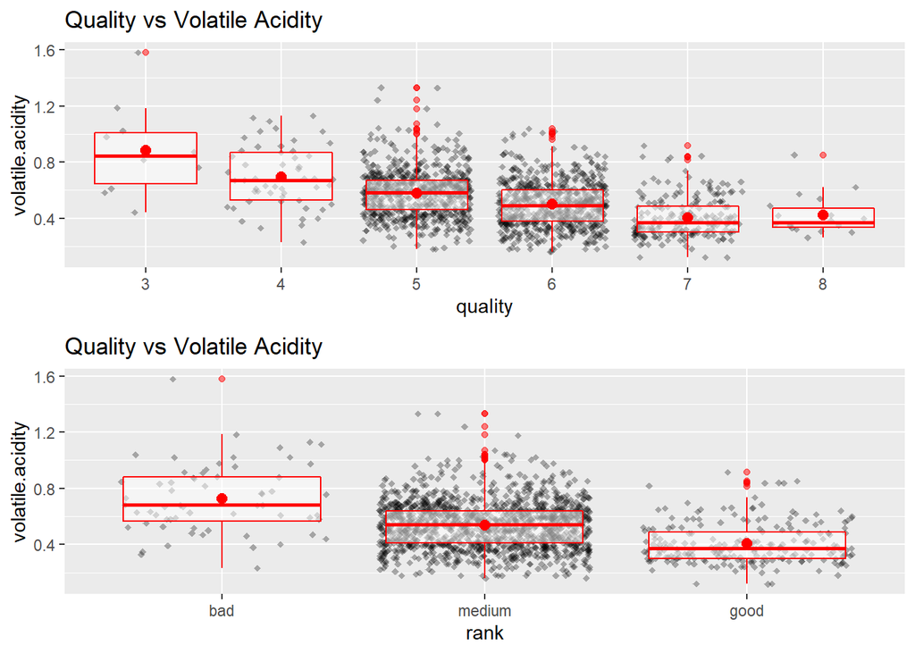

As we can see, the variable Volatile acid seems to have a negative influence on the wine, because as the volatile acid level goes up, the quality / rank of the wine degrades.

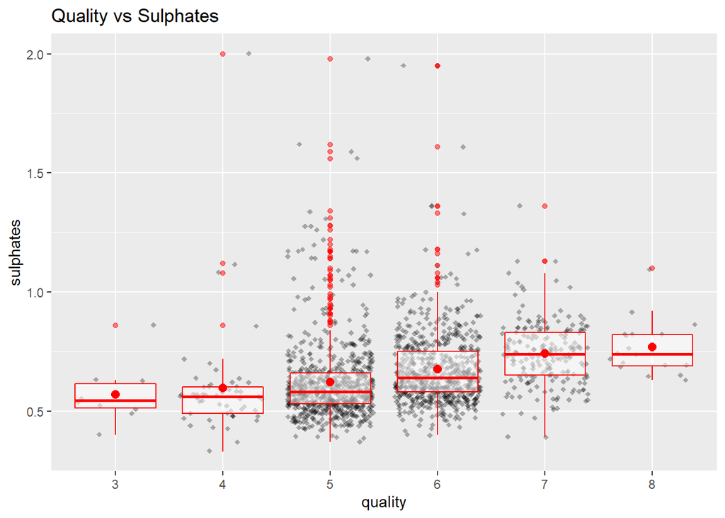

We can see that wines with a have a higher quality value with more sulphates than others that have less amount of sulphates.

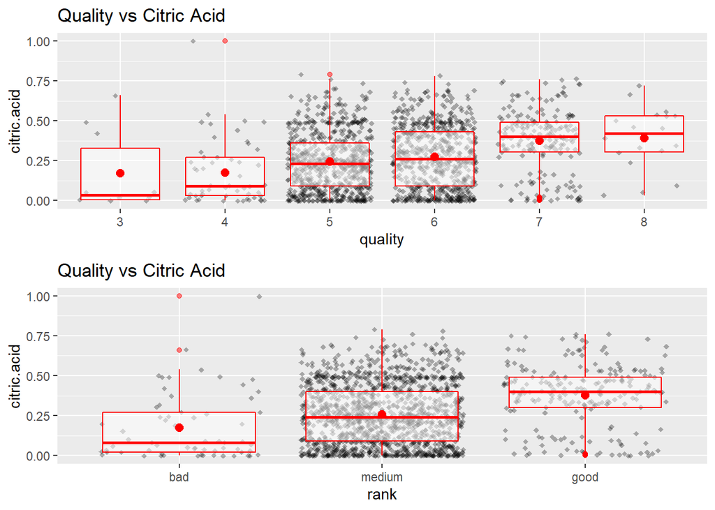

We can see that citric acid have a positive correlation with Wine Quality.

# Bivariate Analysis

### Talk about some of the relationships you observed in this part of the investigation. How did the feature(s) of interest vary with other features in the dataset?

I chose:

Volatile acidity had a negative correlation of -0.39.

Sulphates have a positive correlation of 0.25

### Did you observe any interesting relationships between the other features (not the main feature(s) of interest)?

I found the relationship between free sulfur dioxide and total sulfur dioxide with 0.67 of positive correlation.

### What was the strongest relationship you found?

Citric acid with fixed acidity and total sulfur dioxide with free sulfur dioxide, both have 6.7 of correlation. And about the analysis of the quality of red wine, alcohol and volatile acidity had the strongest relationship

# Multivariate Plots Section

Alcohol seems to play a strong part in the quality of the wine, so now I will first try to insert a few more variables to analyze how much they contribute to the overall quality.

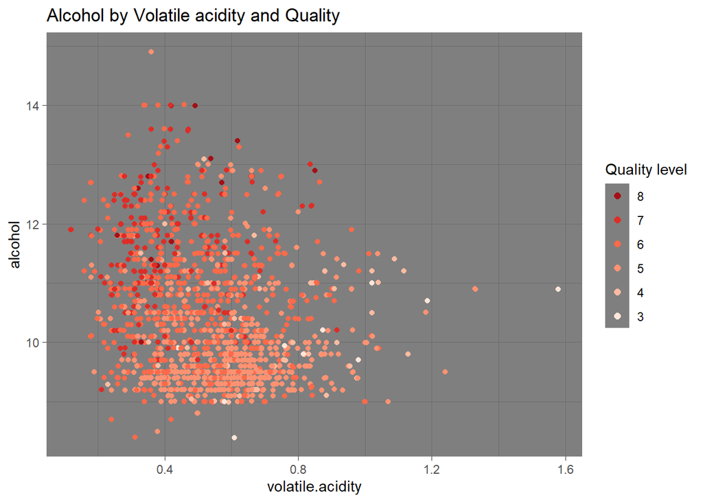

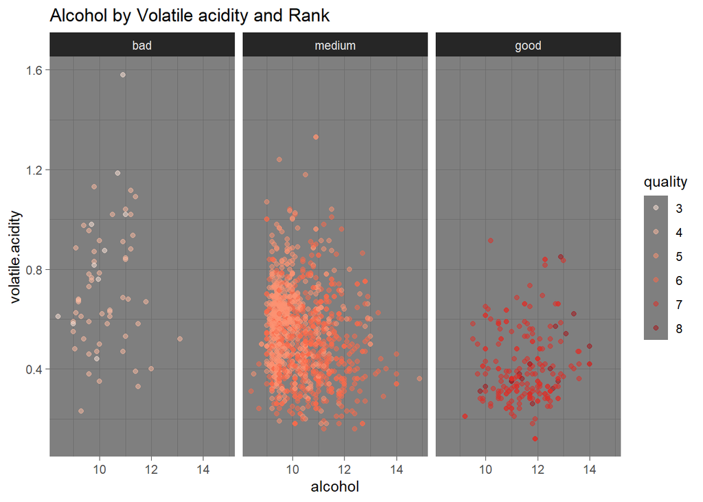

Here we can see that most of the good wines have Values of alcohol above 11% and close to 0.4 of Volatile acidity.

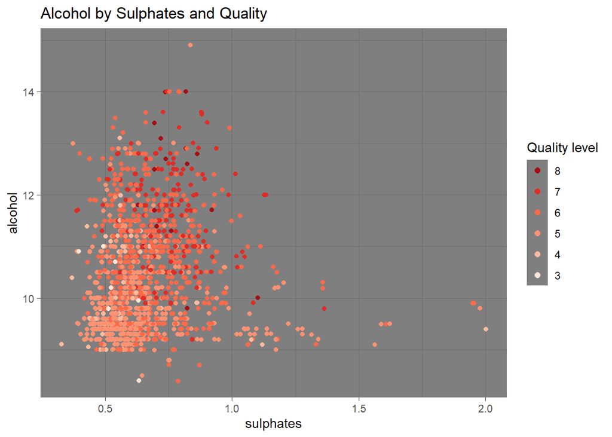

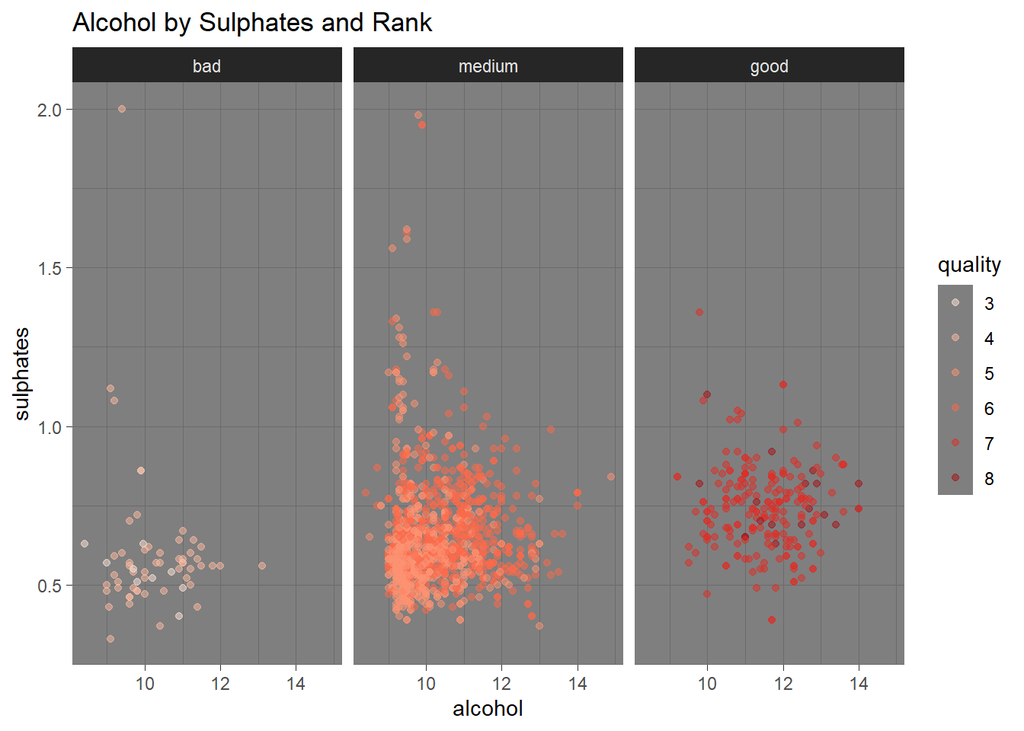

Most of the good wines have Values of alcohol above 11% and between 0.5 an 1 of sulphates, resulting in wines which are quality 7 and above

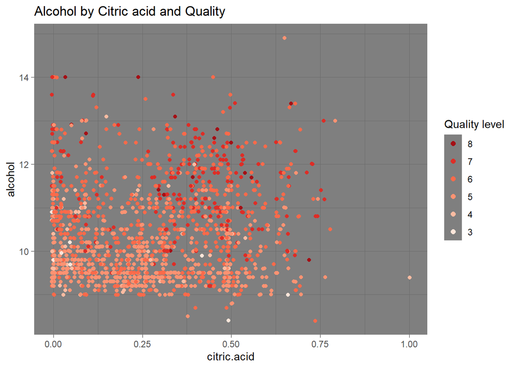

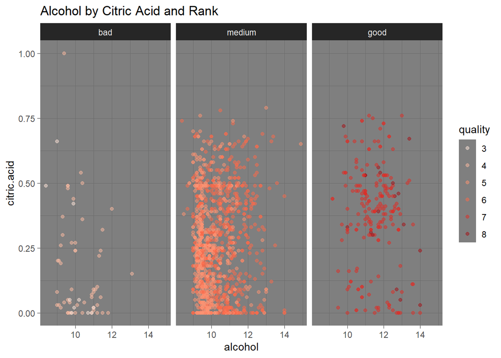

Most of the good wines have Values of alcohol above 11% and 0.25 of citric acid, resulting in wines which are quality 7 and above

# Linear Multivariable Model

This Linear model was created to predict wine quality based on the main chemical properties. The features are selected in order of the correlation between this feature and wine quality.

```r
set.seed(1221)

sample_data <- sample_frac(wines, .6)

test_data <- wines[ !wines$wine.id %in% sample_data$wines$wine.id, ]
m1 <- lm(as.numeric(quality) ~ alcohol, data = wines)
m2 <- update(m1, ~ . + volatile.acidity)
m3 <- update(m2, ~ . + sulphates)
m4 <- update(m3, ~ . + citric.acid)
mtable(m1,m2,m3,m4)
```

```
##
## Calls:
## m1: lm(formula = as.numeric(quality) ~ alcohol, data = wines)
## m2: lm(formula = as.numeric(quality) ~ alcohol + volatile.acidity,
##     data = wines)
## m3: lm(formula = as.numeric(quality) ~ alcohol + volatile.acidity +
##     sulphates, data = wines)
## m4: lm(formula = as.numeric(quality) ~ alcohol + volatile.acidity +
##     sulphates + citric.acid, data = wines)
##
## ========================================================================
##                         m1           m2           m3           m4
## ------------------------------------------------------------------------
##   (Intercept)         -0.125        1.095***     0.611**      0.646**
##                       (0.175)      (0.184)      (0.196)      (0.201)
##   alcohol              0.361***     0.314***     0.309***     0.309***
##                       (0.017)      (0.016)      (0.016)      (0.016)
##   volatile.acidity                 -1.384***    -1.221***    -1.265***
##                                    (0.095)      (0.097)      (0.113)
##   sulphates                                      0.679***     0.696***
##                                                 (0.101)      (0.103)
##   citric.acid                                                -0.079
##                                                              (0.104)
## ------------------------------------------------------------------------
##   R-squared            0.227        0.317        0.336        0.336
##   N                 1599         1599         1599         1599
## ========================================================================
##   Significance: *** = p < 0.001; ** = p < 0.01; * = p < 0.05
```

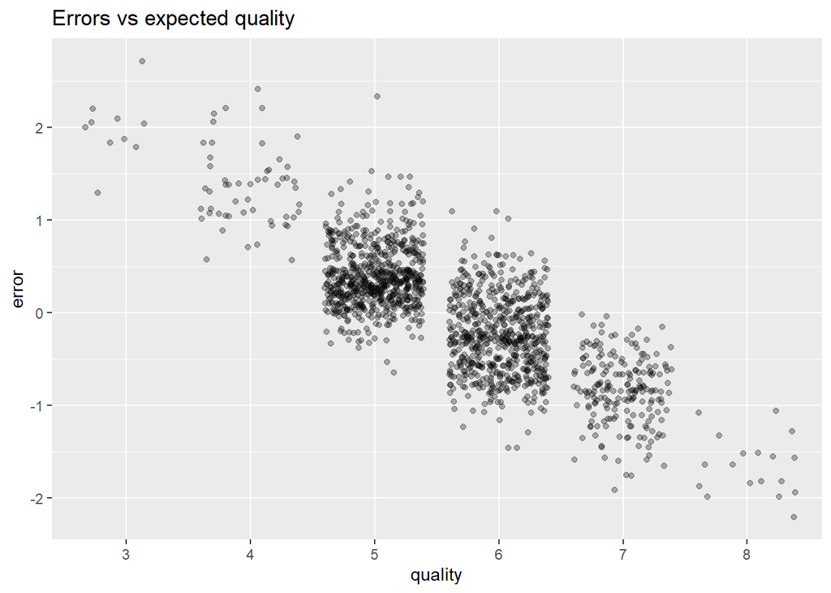

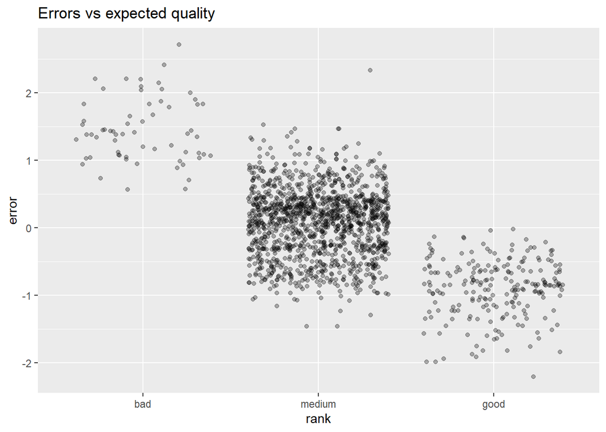

# Multivariate Analysis

### Talk about some of the relationships you observed in this part of the investigation. Were there features that strengthened each other in terms of looking at your feature(s) of interest?

Yes, I find out that higher Citric Acid and lower Volatile Acidity contribute towards better wines. Also, better wines tend to have higher alcohol content.

## Since our dataset comprised mainly of ‘Average’ quality wines and as there just a very few data about the ‘Good’ and the ‘Bad’ quality wines in the dataset, it can difficult to predict statistics for the edge cases.

# Final Plots and Summary

### Plot One

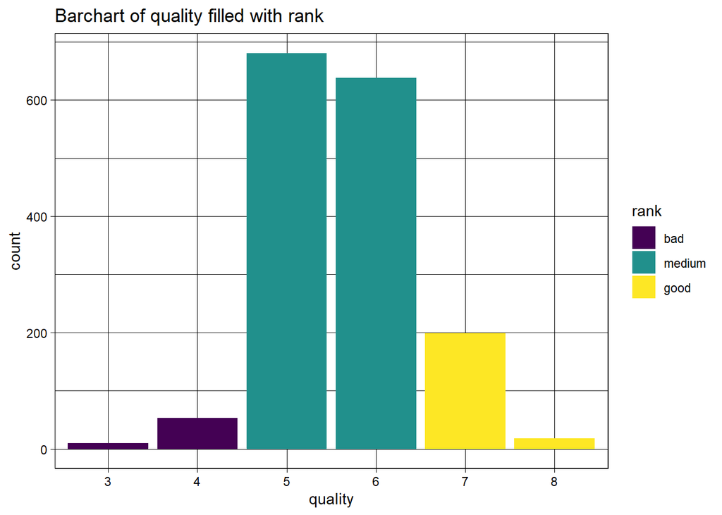

### Description One

This graph is important, it shows how distributed is our data and gives us the idea that the data is unbalanced, we need to keep that in mind when we analyze the variables.

### Plot Two

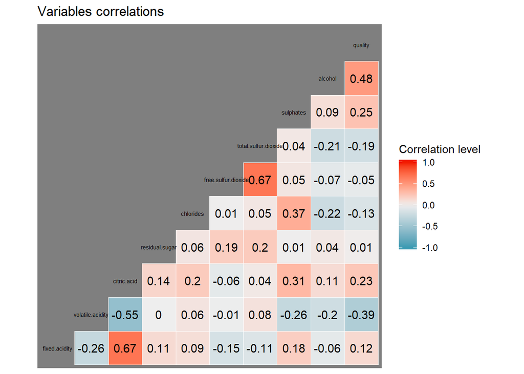

### Description Two

I think this graph is important, It shows the correlation between our variables, with him we com choose which variables we will use to analyze to find the answer to the main question. Notice that this one is focused on the chemical variables, so I didn’t include the variables of density and pH.

### Plot Three

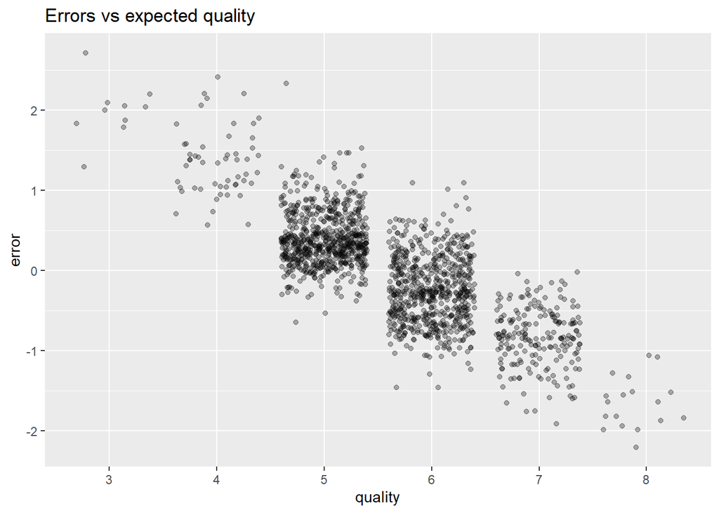

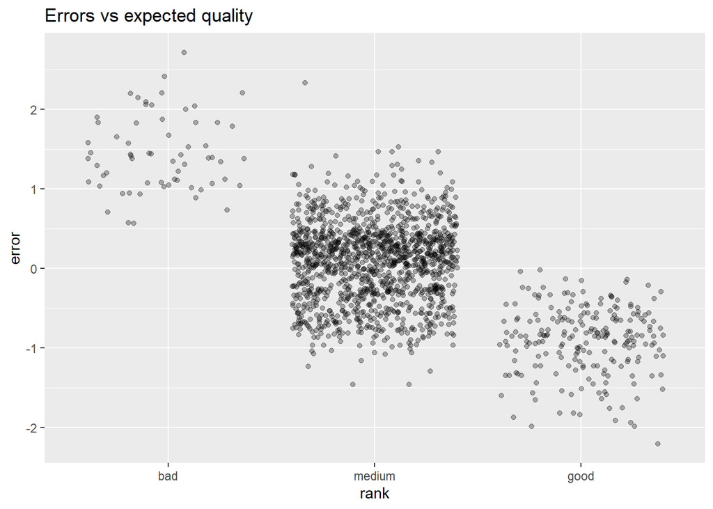

### Description Three

This graph shows the density of the data around the Medium level of quality. That corroborates with the plot of quality count and shot the fact that most of our dataset contains ‘medium’ quality wines and there is not too many data in the extreme ranges. with difficult the task of the best model to predict both ‘Good’ and ‘Bad’ quality wines.

# Reflection

he red wine dataset contains 1,599 observation, 13 variables associated to them (1 id variable + 11 attributes variables + 1 output variable). Looking in the documentation, it specifies that the dataset is not balanced, and looking into it I how much the dataset is unbalanced. The data set for medium quality wine covered above 80% of the distribution.

Also, the documentation mentions that the complete data set have the number of Instances: red wine - 1599; white wine - 4898.

With that, I knew that the correlations may be altered and that my linear model would have more difficult to predict good and bad wines than the medium ones.

These variables are:

Alcohol: The N.1 factor correlated to the wine quality. The data suggests that the higher the alcohol content, the more likely the better wine quality with 0.48.

Volatile Acidity: volatile acidity has the strongest negative correlation to wine quality with -0.39.

Sulphates: Sulphates has a positive correlation with wine quality with 0.25.

Citic acids: Has a positive correlation with wine quality with 0.23.

If the dataset had more observations with both good and bad wines, the quality of analysis would be a lot better, having these observations and maybe some more variables included, the dataset would result in differents insight altogether on the analysis.